# 12 SUPPORT VECTOR MACHINE

## 12.1 Linear Support Vector Machines

### The Separable Case

#### Problem Statement

- Training set:
  $$(\boldsymbol{x}_{i},y_{i})_{i=1...N}\in\mathbb{R}^{D}\times\left\{ -1,1\right\}$$
- We would like to find an hyperplane
  $${\color{red}\boldsymbol{w}}^{\intercal}\boldsymbol{x}+{\color{red}b}=0,\quad({\color{red}\boldsymbol{w}}\in\mathbb{R}^{D},{\color{red}b}\in\mathbb{R})$$
  which **separates** the two classes.

#### Margin

- Let $d_{+}$ be the shortest distance from the hyperplane to the closest positive example.
- Let $d_{-}$ be the shortest distance from the hyperplane to the closest negative example.
- Define the **margin** of the hyperplane to be $\min(d_{+},d_{-})$.

[figure not shown]

#### Better Linear Separation

[figure not shown]

Two questions:

1. Why is bigger margin better?
2. Which ${\color{red}\boldsymbol{w}},{\color{red}b}$ maximizes the margin

#### Why is it Good to Maximize the Margin?

- If training and test data come from the same distribution and all test data are within some $\Delta$ distance from the training points. If all points lie at a distance of at least $\Delta$ from the separator, and all points are in a bounded sphere, then a small perturbation of the definition of the separator will not hurt.

[figure not shown]

- One can use less bits to encode the separating hyperplane (**Minimum Description Length** principle)

[figure not shown]

#### Finding $\boldsymbol{w}$ with large margin

- Let $\boldsymbol{x}_{n}$ be the nearest data point to the plane ${\color{red}\boldsymbol{w}}^{\intercal}\boldsymbol{x}+{\color{red}b}=0$. How far is it?

[figure not shown]

- The distance between $\boldsymbol{x}_{n}$ and the plane ${\color{red}\boldsymbol{w}}^{\intercal}\boldsymbol{x}+{\color{red}b}=0$ where $\left|{\color{red}\boldsymbol{w}}^{\intercal}\boldsymbol{x}_{n}+{\color{red}b}\right|=1$ (normalize ${\color{red}\boldsymbol{w}}$ and $b$)
  $$\begin{equation}
  distance=\frac{1}{\left|{\color{red}\boldsymbol{w}}\right|}
  \end{equation}$$

#### A Constrained Optimization Problem

- Representation of hypothesis set
  $$\begin{equation}
  \mathcal{H}:y=f(\boldsymbol{x})=\text{sign}({\color{red}\boldsymbol{w}}\cdot\boldsymbol{x}+{\color{red}b})
  \end{equation}$$
- Evaluation

$$\begin{align}
& \arg\min_{{\color{red}\boldsymbol{w}},{\color{red}b}} & \frac{1}{2}\|{\color{red}\boldsymbol{w}}\|^{2}\\
& \text{subject to} & y_{i}({\color{red}\boldsymbol{w}}\cdot\boldsymbol{x}_{i}+{\color{red}b})\geq1,\quad i=1,2,\dots,N
\end{align}$$

#### The Dual Formulation

- Representation of hypothesis set
  $$\begin{equation}
  \mathcal{H}:y=f(\boldsymbol{x})=\text{sign}\left(\sum\limits_{i=1}^{N}{\color{red}\alpha_{i}}y_{i}(\boldsymbol{x}\cdot\boldsymbol{x}_{i})+{\color{red}b}\right)
  \end{equation}$$
- Evaluation
  $$\begin{align}
  & \arg\min_{{\color{red}\boldsymbol{\alpha}}} & \frac{1}{2}\sum\limits_{i=1}^{N}\sum\limits_{j=1}^{N}{\color{red}\alpha_{i}\alpha_{j}}y_{i}y_{j}(\boldsymbol{x}_{i}\cdot\boldsymbol{x}_{j})-\sum\limits_{i=1}^{N}{\color{red}\alpha_{i}}\\
  & \text{subject to} & \sum\limits_{i=1}^{N}{\color{red}\alpha_{i}}y_{i}=0\\
  & & {\color{red}\alpha_{i}}\geq0,\quad i=1,2,\dots,N
  \end{align}$$
- This can be solved using classical **quadratic programming optimization**

### The Non-Separable Case

#### Bug

- This minimization problem does not have any solution if the two classes are not separable.

[figure not shown]

#### Fixing The Bug: “Soft” Margin

- Relax the constraints: use a **soft margin** instead of a **hard margin**.
- We would like to minimize:

$$\begin{align}
& \arg\min_{{\color{red}\boldsymbol{w}},{\color{red}b},{\color{red}\boldsymbol{\xi}}} & \frac{1}{2}\|{\color{red}\boldsymbol{w}}\|^{2}+{\color{green}C}\sum\limits_{i=1}^{N}{\color{red}\xi_{i}}\\
& \text{subject to} & y_{i}({\color{red}\boldsymbol{w}}\cdot\boldsymbol{x}_{i}+{\color{red}b})\geq1-{\color{red}\xi_{i}}\\
& & {\color{red}\xi_{i}}\geq0,\quad i=1,2,\dots,N
\end{align}$$

#### The Dual Formulation

- Representation of hypothesis set
  $$\begin{equation}
  \mathcal{H}:y=f(\boldsymbol{x})=\text{sign}\left(\sum\limits_{i=1}^{N}{\color{red}\alpha_{i}}y_{i}(\boldsymbol{x}\cdot\boldsymbol{x}_{i})+{\color{red}b}\right)
  \end{equation}$$
- Evaluation
  $$\begin{align}
  & \arg\min_{{\color{red}\boldsymbol{\alpha}}} & \frac{1}{2}\sum\limits_{i=1}^{N}\sum\limits_{j=1}^{N}{\color{red}\alpha_{i}\alpha_{j}}y_{i}y_{j}(\boldsymbol{x}_{i}\cdot\boldsymbol{x}_{j})-\sum\limits_{i=1}^{N}{\color{red}\alpha_{i}}\\
  & \text{subject to} & \sum\limits_{i=1}^{N}{\color{red}\alpha_{i}}y_{i}=0\\
  & & 0\leq{\color{red}\alpha_{i}}\leq{\color{green}C},\quad i=1,2,\dots,N
  \end{align}$$

#### Support Vector Terminology

- Training examples $\boldsymbol{x}_{i}$ with $\alpha_{i}>0$ are **support vectors**.
  $$\begin{align}
  {\color{red}\alpha_{i}}=0\Rightarrow y_{i}({\color{red}\boldsymbol{w}}\cdot\boldsymbol{x}_{i}+{\color{red}b})>1\nonumber \\
  {\color{red}\alpha_{i}}={\color{green}C}\Rightarrow y_{i}({\color{red}\boldsymbol{w}}\cdot\boldsymbol{x}_{i}+{\color{red}b})<1\\
  0<{\color{red}\alpha_{i}}<{\color{green}C}\Rightarrow y_{i}({\color{red}\boldsymbol{w}}\cdot\boldsymbol{x}_{i}+{\color{red}b})=1\nonumber
  \end{align}$$

[figure not shown]

## 12.2 Kernels Support Vector Machines

#### Non-Linear SVMs

- Project the data into a **higher dimensional space** (**feature space**): it should be easier to separate the two classes.
- Given a function $\phi:\mathbb{R}^{D}\to\mathcal{F}$, work with $\phi(\boldsymbol{x}_{i})$ instead of working with $\boldsymbol{x}_{i}$.

[figure not shown]

#### The Kernel Function

A **kernel** is a function $k(\boldsymbol{x},\boldsymbol{z})$ which represents a dot product in a “hidden” feature space of $\phi$.
$$\begin{equation}
k(\boldsymbol{x},\boldsymbol{z})=\phi(\boldsymbol{x})\cdot\phi(\boldsymbol{z})
\end{equation}$$

- **Note that**: we have only dot products $\phi(\boldsymbol{x}_{i})\cdot\phi(\boldsymbol{x}_{j})$ to compute; however, this could be very expensive in a high dimensional space.
- **Kernel trick**:

  instead of $\phi(\boldsymbol{x})=\phi\left(\begin{array}{c} x_{1}\\ x_{2} \end{array}\right)=\left(\begin{array}{c} x_{1}^{2}\\ \sqrt{2}x_{1}x_{2}\\ x_{2}^{2} \end{array}\right)$, use $k(\boldsymbol{x},\boldsymbol{z})=(\boldsymbol{x}\cdot\boldsymbol{z})^{2}$

#### Common Kernels

- Polynomial:
  $$\begin{equation}
  k(\boldsymbol{x},\boldsymbol{z})=(u\boldsymbol{x}\cdot\boldsymbol{z}+v)^{p}\;(u\in\mathbb{R},v\in\mathbb{R},p\in\mathbb{N})
  \end{equation}$$
- Gaussian:
  $$\begin{equation}
  k(\boldsymbol{x},\boldsymbol{z})=\exp\left(-\frac{\left\Vert \boldsymbol{x}-\boldsymbol{z}\right\Vert ^{2}}{{\color{green}\sigma}^{2}}\right)\;,{\color{green}\sigma}\in\mathbb{R}^{+}
  \end{equation}$$

#### Techniques for Construction of Kernels

In all the following, $k_{1},k_{2},...,k_{j}$ are assumed to be valid kernel functions

1. **Scalar multiplication**: The validity of a kernel is conserved after multiplication by a positive scalar, i.e., for any $\alpha>0$, the function
   $$\begin{equation}
   k(\boldsymbol{x},\boldsymbol{z})=\alpha k_{1}(\boldsymbol{x},\boldsymbol{z})
   \end{equation}$$
2. **Adding a positive constant**: For any positive constant $\alpha>0$, the function
   $$\begin{equation}
   k(\boldsymbol{x},\boldsymbol{z})=\alpha+k_{1}(\boldsymbol{x},\boldsymbol{z})
   \end{equation}$$
3. **Linear combination**: A linear combination of kernel functions involving only positive weights, i.e.,
   $$\begin{equation}
   k(\boldsymbol{x},\boldsymbol{z})=\sum_{j=1}^{m}\alpha_{j}k_{j}(\boldsymbol{x},\boldsymbol{z}),\qquad\text{with }\alpha_{j}>0
   \end{equation}$$
   is a valid kernel function.
4. **Product**: The product of two kernel functions, i.e.,
   $$\begin{equation}
   k(\boldsymbol{x},\boldsymbol{z})=k_{1}(\boldsymbol{x},\boldsymbol{z})k_{2}(\boldsymbol{x},\boldsymbol{z})
   \end{equation}$$
   is a valid kernel function.
5. **Polynomial functions of a kernel output**: Given a polynomial $f:\mathbb{R}\to\mathbb{R}$ with positive coefficients, the function
   $$\begin{equation}
   k(\boldsymbol{x},\boldsymbol{z})=f(k_{1}(\boldsymbol{x},\boldsymbol{z}))
   \end{equation}$$
   is a valid kernel function.
6. **Exponential function of a kernel output**: The function
   $$\begin{equation}
   k(\boldsymbol{x},\boldsymbol{z})=\exp(k_{1}(\boldsymbol{x},\boldsymbol{z}))
   \end{equation}$$
   is a valid kernel function.
7. **Product of matrix** and **vectors**:
   $$\begin{equation}
   k(\boldsymbol{x},\boldsymbol{z})=\boldsymbol{x}^{\intercal}A\boldsymbol{z}
   \end{equation}$$
   where $A$ is a symmetric positive semidefinite matrix.

#### Decision Boundary and Support Vectors

[figure not shown]

#### SVMs in Practice

- In order to tune the **capacity**, the kernel is the most important parameter to choose.
  - Polynomial kernel: increasing the degree will increase the **capacity**.
  - Gaussian kernel: increasing ${\color{green}\sigma}$ will decrease the capacity.
- Tune ${\color{green}C}$, the trade-off between the **margin** and the **errors**.
  - For non-noisy data sets, ${\color{green}C}$ usually has not much influence.
  - Carefully choose ${\color{green}C}$ for noisy data sets: small values usually give better results.

## 12.3 Multi-class SVM

#### Multiclass SVM formulations

- There are a few ways of formulating the SVM over multiple classes:
  - One-vs-all
  - One-vs-one
  - Hierarchical
  - **Multiclass**

#### Score function

The **score function** $f$ that maps the raw features to class scores.
$$\begin{equation}
\boldsymbol{z}=f(\boldsymbol{x};{\color{red}W})={\color{red}W}\boldsymbol{x}
\end{equation}$$

[figure not shown]

#### Multiclass SVM loss

- Given the input vector $\boldsymbol{x}_{i}$ and the label $y_{i}$ that specifies the index of the correct class. The multiclass SVM loss (**hinge loss**) for the vector $\boldsymbol{x}_{i}$ is then formalized as follows
  $$\begin{equation}
  L_{i}=\sum_{j\neq y_{i}}\max(0,z_{j}-z_{y_{i}}+{\color{green}\Delta})
  \end{equation}$$
  where $\boldsymbol{z}=f(\boldsymbol{x}_{i};{\color{red}W})={\color{red}W}\boldsymbol{x}_{i}$

#### Example

- Suppose that we have five classes $\{0,1,2,3,4\}$ that receive the scores $\boldsymbol{z}=[17,4,15,6,8]$ and the true class $y_{i}=0$
- Also assume that ${\color{green}\Delta}=10$

$$\begin{align*}
L_{i} & =\max(0,4-17+10)+\max(0,15-17+10)\\
& +\max(0,6-17+10)+\max(0,8-17+10)=9
\end{align*}$$

[figure not shown]

#### Regularization loss

- The most common regularization penalty is the $L_{2}$ norm that discourages large weights through an elementwise quadratic penalty over all parameters:
  $$\begin{equation}
  R(W)=\sum_{k}\sum_{l}{\color{red}W}_{k,l}^{2}
  \end{equation}$$
- The data loss (which is the average loss $L_{i}$ over all examples) and the regularization loss. That is, the full multiclass SVM loss becomes:
  $$\begin{equation}
  \mathcal{L}=\mathcal{L}_{\text{data}}+\mathcal{L}_{\text{reg}}=\underbrace{\frac{1}{N}\sum_{i}L_{i}}_{\text{data loss}}+\underbrace{{\color{green}\lambda}R({\color{red}W})}_{\text{regularization loss}}
  \end{equation}$$
- **Learning goal**: Find ${\color{red}W}$ that minimize
  $$\begin{equation}
  \arg\min_{{\color{red}W}}\mathcal{L}
  \end{equation}$$

#### Practical considerations

- **Setting Delta**: It can safely be set to ${\color{green}\Delta}=1.0$ in all cases
- **Relation to Binary Support Vector Machine**: The loss for the $i$-th example $(\boldsymbol{x}_{i},y_{i})$ can be written as
  $$\begin{equation}
  L_{i}={\color{green}C}\max(0,1-y_{i}{\color{red}\boldsymbol{w}}^{\intercal}\boldsymbol{x}_{i})+R({\color{red}\boldsymbol{w}})
  \end{equation}$$
  where ${\color{green}C}$ is a hyperparameter, and $y_{i}\in\{-1,1\}$

#### Binary classification losses

- Perceptron (zero-one)
- SVM (hinge)
- Logistic

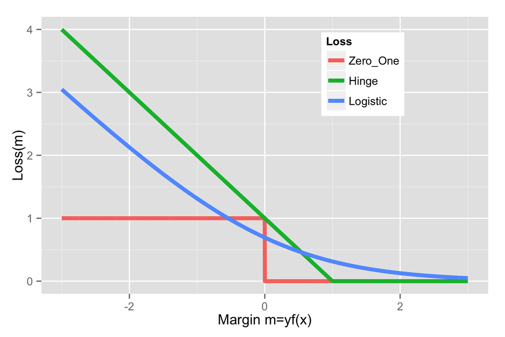

#### SGD for hinge loss

- Consider linear hypothesis space:
  $$\begin{equation}
  h_{{\color{red}\boldsymbol{w}}}(\boldsymbol{x})={\color{red}\boldsymbol{w}}^{\intercal}\boldsymbol{x}
  \end{equation}$$
- Hinge loss of $(\boldsymbol{x},y)$
  $$\begin{equation}
  \mathcal{L}(x)=\max(0,1-y{\color{red}\boldsymbol{w}}^{\intercal}\boldsymbol{x})
  \end{equation}$$
- Gradient of hinge loss $(\boldsymbol{x},y)$:
  $$\begin{equation}
  \nabla_{{\color{red}\boldsymbol{w}}}\mathcal{L}(\boldsymbol{x})=\begin{cases}
  -y\boldsymbol{x} & \text{if }yh_{{\color{red}\boldsymbol{w}}}(\boldsymbol{x})<1\\
  0 & \text{if }yh_{{\color{red}\boldsymbol{w}}}(\boldsymbol{x})>1\\
  \text{undefined} & \text{if }yh_{{\color{red}\boldsymbol{w}}}(\boldsymbol{x})=1
  \end{cases}
  \end{equation}$$
- A point with margin $m=yh_{{\color{red}\boldsymbol{w}}}(\boldsymbol{x})=1$ is correctly classified $\to$ we can skip SGD update for these points.

## 12.4 References

[video not shown]